# 利用迴歸分析完成解釋性預測

沈辰禧，台灣大學商研碩士

2018年8月

個案最終的目標不僅是要預測營收，而是要完成系統化、可以溝通並維護的預測。我們必須遵循較嚴謹的資料分析流程，從探索性資料分析開始，建立假說；並透過驗證假說的過程，完成最後的模型。

## 資料輸入與前處理

### 讀取資料以及需要的library

```r
library(tidyverse)
library(knitr)

SalesData <- read.csv('Restaurant_Sales.csv')

kable( SalesData[1:10,], row.names = F, caption = '原始資料')
```

原始資料

| Store_Name | Region | Type | Weekday | Month | Sales |
| --- | --- | --- | --- | --- | --- |
| 1 | A | AA | Weekday | Jan | 61508 |
| 1 | A | AA | Weekday | Jan | 62358 |
| 1 | A | AA | Weekday | Jan | 61579 |
| 1 | A | AA | Weekday | Jan | 57747 |
| 1 | A | AA | Weekday | Jan | 52169 |
| 1 | A | AA | Weekend | Jan | 63197 |
| 1 | A | AA | Weekend | Jan | 65528 |
| 1 | A | AA | Weekday | Jan | 56107 |
| 1 | A | AA | Weekday | Jan | 64067 |
| 1 | A | AA | Weekday | Jan | 46116 |

## 探索性資料分析

不論是什麼樣的題目，都還是要從我們再熟悉不過的EDA開始著手。 從目前的資料中，我們可以知道有，可能影響營收的變數：

- Store_Name： 店別
- Region：所在區域，A為觀光區，B為商業區
- Type： 門市類型，AA為百貨門市，BB為獨立門市
- Day_Type：日別
- Month：月份

因此，我們可以試著用簡單的視覺化，根據不同變數建立假說

### 各店的銷售分配

店1和店4的營收較高，變異也較大；店2和店3雖然營收較低，但較為集中

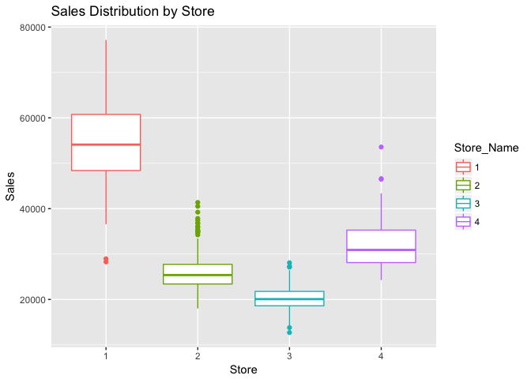

```r
SalesData$Store_Name <- as.factor(SalesData$Store_Name)


ggplot(data = SalesData) + geom_boxplot(aes( x= Store_Name, y= Sales, colour = Store_Name)) +
  labs( x = 'Store',
        y = 'Sales',
        title = 'Sales Distribution by Store')
```

### 各區域的銷售分配

區域A和區域B的營收分佈有較大的差異

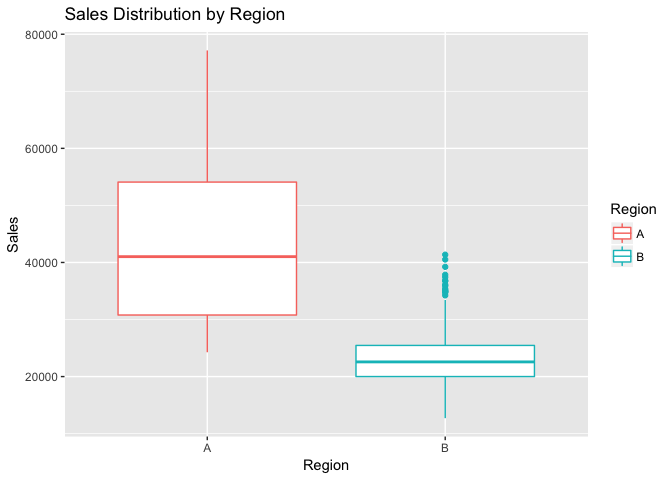

```r
ggplot(data = SalesData) + geom_boxplot(aes( x = Region, y = Sales,colour = Region)) +
  labs( x = 'Region',
        y = 'Sales',
        title = 'Sales Distribution by Region')
```

### 各門市類型的銷售分配

百貨門市(AA)和獨立門市(BB)相比，營收較高

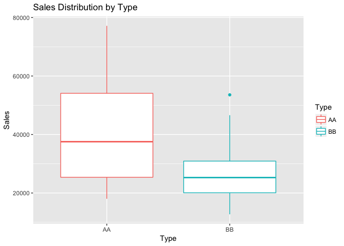

```r
ggplot(data = SalesData) + geom_boxplot(aes( x = Type, y = Sales, colour = Type)) +
  labs( x = 'Type',
        y = 'Sales',
        title = 'Sales Distribution by Type')
```

### 各店間的平假日銷售分配

四間店平日和假日的銷售分佈不盡相同

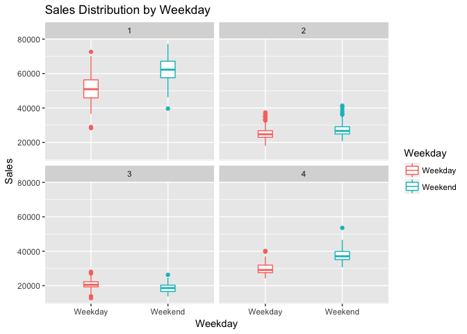

```r
ggplot(data = SalesData) + geom_boxplot(aes( x = Weekday, y = Sales, colour = Weekday)) +

  facet_wrap(~ Store_Name) +

  labs( x = 'Weekday',
        y = 'Sales',
        title = 'Sales Distribution by Weekday')
```

### 各店間的月份銷售分配

四間店在各月份的銷售分佈也不盡相同

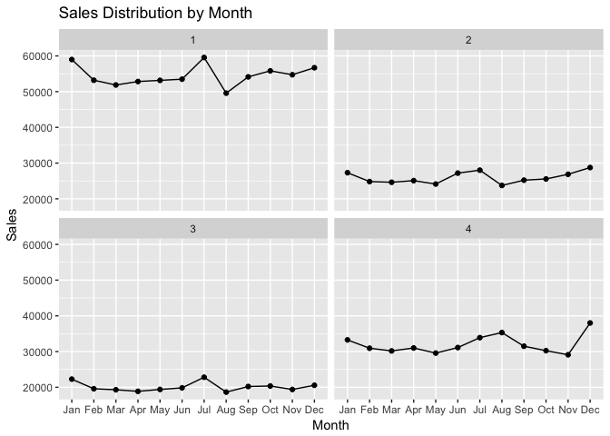

```r
SalesData$Month <- factor(SalesData$Month, levels = c('Jan','Feb','Mar','Apr','May','Jun','Jul','Aug','Sep','Oct','Nov','Dec'))

SalesDatabyMonth <- SalesData %>%
  group_by( Store_Name,Month) %>%
  summarise( SalesMean = mean(Sales))

ggplot(data = SalesDatabyMonth,aes( x = Month, y = SalesMean)) + geom_point() + geom_line() +

  facet_wrap(~ Store_Name) +

  labs( x = 'Month',
        y = 'Sales',
        title = 'Sales Distribution by Month')
```

在確認完所有的變數後，我們可以簡單地辨識出變數中不同levels，彼此之間的差異，這是接下來迴歸分析建模的重要基礎(就如同之前每一個案例)。

## 迴歸分析

迴歸分析主要會用到的函數是`lm()`，意思是Linear Model。主要使用到的參數有兩個：

- formula: `Y ~ X1 + X2`，Y是反應變數，X1和X2是解釋變數。
- data: 要分析的資料集合名稱。

這個類型的物件裡面包含很多內容，用來描述模型的細節。如果要呼叫摘要，一樣使用`summary()`。

### 依區域分開建模

由於我們發現區域(Region)之間的營業額有較明顯的差異，但在其他變數中營業額的分布各有不同，因此我們先依照區域切分資料，探討其他變數的影響。

```r
DataA <- SalesData %>%
  filter( Region %in% 'A')
DataB <- SalesData %>%
  filter( Region %in% 'B')
```

#### 驗證假說一：門市類型的差異

```r
Model.A.Type <- lm( Sales ~ Type, data = DataA)
Model.B.Type <- lm( Sales ~ Type, data = DataB)
```

對於這兩個區域而言，門市類型的差異有非常顯著的影響，`R-squared`分別是0.72和0.46，具有相當不錯的解釋能力。

```r
summary(Model.A.Type)
```

```
##
## Call:
## lm(formula = Sales ~ Type, data = DataA)
##
## Residuals:
##      Min       1Q   Median       3Q      Max
## -26250.3  -4464.3   -770.8   4487.1  22641.7
##
## Coefficients:
##             Estimate Std. Error t value Pr(>|t|)
## (Intercept)  54522.3      366.6  148.72   <2e-16 ***
## TypeBB      -22486.0      518.5  -43.37   <2e-16 ***
## ---
## Signif. codes:  0 '***' 0.001 '**' 0.01 '*' 0.05 '.' 0.1 ' ' 1
##
## Residual standard error: 7004 on 728 degrees of freedom
## Multiple R-squared:  0.721,  Adjusted R-squared:  0.7206
## F-statistic:  1881 on 1 and 728 DF,  p-value: < 2.2e-16
```

```r
summary(Model.B.Type)
```

```
##
## Call:
## lm(formula = Sales ~ Type, data = DataB)
##
## Residuals:
##     Min      1Q  Median      3Q     Max
## -7924.7 -2060.5  -326.9  1670.9 15414.3
##
## Coefficients:
##             Estimate Std. Error t value Pr(>|t|)
## (Intercept)  25951.7      167.3  155.08   <2e-16 ***
## TypeBB       -5835.6      236.7  -24.66   <2e-16 ***
## ---
## Signif. codes:  0 '***' 0.001 '**' 0.01 '*' 0.05 '.' 0.1 ' ' 1
##
## Residual standard error: 3197 on 728 degrees of freedom
## Multiple R-squared:  0.4551, Adjusted R-squared:  0.4543
## F-statistic:   608 on 1 and 728 DF,  p-value: < 2.2e-16
```

#### 驗證假說二：假日的差異

```r
Model.A.Week <- lm( Sales ~ Weekday, data = DataA)
Model.B.Week <- lm( Sales ~ Weekday, data = DataB)
```

平日假日對於區域A而言雖有顯著的差異，但對整體營收變化的解釋力較弱；對於區域B而言，並沒有顯著的差異及影響。

```r
summary(Model.A.Week)
```

```
##
## Call:
## lm(formula = Sales ~ Weekday, data = DataA)
##
## Residuals:
##    Min     1Q Median     3Q    Max
## -19130 -11866  -3482  11397  31923
##
## Coefficients:
##                Estimate Std. Error t value Pr(>|t|)
## (Intercept)     40665.2      551.2  73.772   <2e-16 ***
## WeekdayWeekend   9174.5     1032.7   8.884   <2e-16 ***
## ---
## Signif. codes:  0 '***' 0.001 '**' 0.01 '*' 0.05 '.' 0.1 ' ' 1
##
## Residual standard error: 12590 on 728 degrees of freedom
## Multiple R-squared:  0.09782,    Adjusted R-squared:  0.09658
## F-statistic: 78.93 on 1 and 728 DF,  p-value: < 2.2e-16
```

```r
summary(Model.B.Week)
```

```
##
## Call:
## lm(formula = Sales ~ Weekday, data = DataB)
##
## Residuals:
##      Min       1Q   Median       3Q      Max
## -10321.2  -3028.2   -463.2   2426.6  18327.7
##
## Coefficients:
##                 Estimate Std. Error t value Pr(>|t|)
## (Intercept)    23032.159    189.569 121.497   <2e-16 ***
## WeekdayWeekend     6.153    355.138   0.017    0.986
## ---
## Signif. codes:  0 '***' 0.001 '**' 0.01 '*' 0.05 '.' 0.1 ' ' 1
##
## Residual standard error: 4331 on 728 degrees of freedom
## Multiple R-squared:  4.124e-07,  Adjusted R-squared:  -0.001373
## F-statistic: 0.0003002 on 1 and 728 DF,  p-value: 0.9862
```

#### 驗證假說三：月份的差異

```r
Model.A.Month <- lm( Sales ~ Month, data = DataA)
Model.B.Month <- lm( Sales ~ Month, data = DataB)
```

```r
summary(Model.A.Month)
```

```
##
## Call:
## lm(formula = Sales ~ Month, data = DataA)
##
## Residuals:
##    Min     1Q Median     3Q    Max
## -18812 -12639  -2565  10898  33913
##
## Coefficients:
##             Estimate Std. Error t value Pr(>|t|)
## (Intercept)  46129.5     1674.1  27.555   <2e-16 ***
## MonthFeb     -4064.8     2430.1  -1.673   0.0948 .
## MonthMar     -5104.8     2367.5  -2.156   0.0314 *
## MonthApr     -4212.2     2387.1  -1.765   0.0781 .
## MonthMay     -4762.6     2367.5  -2.012   0.0446 *
## MonthJun     -3825.3     2387.1  -1.602   0.1095
## MonthJul       596.5     2367.5   0.252   0.8012
## MonthAug     -3683.3     2367.5  -1.556   0.1202
## MonthSep     -3311.9     2387.1  -1.387   0.1658
## MonthOct     -3094.2     2367.5  -1.307   0.1916
## MonthNov     -4212.2     2387.1  -1.765   0.0781 .
## MonthDec      1221.0     2367.5   0.516   0.6062
## ---
## Signif. codes:  0 '***' 0.001 '**' 0.01 '*' 0.05 '.' 0.1 ' ' 1
##
## Residual standard error: 13180 on 718 degrees of freedom
## Multiple R-squared:  0.02525,    Adjusted R-squared:  0.01032
## F-statistic: 1.691 on 11 and 718 DF,  p-value: 0.07117
```

```r
summary(Model.B.Month)
```

```
##
## Call:
## lm(formula = Sales ~ Month, data = DataB)
##
## Residuals:
##     Min      1Q  Median      3Q     Max
## -9846.2 -2959.4  -421.4  2568.6 16711.8
##
## Coefficients:
##             Estimate Std. Error t value Pr(>|t|)
## (Intercept)  24793.5      528.7  46.893  < 2e-16 ***
## MonthFeb     -2587.9      767.5  -3.372 0.000787 ***
## MonthMar     -2820.6      747.7  -3.772 0.000175 ***
## MonthApr     -2817.5      753.9  -3.737 0.000201 ***
## MonthMay     -3026.8      747.7  -4.048 5.73e-05 ***
## MonthJun     -1275.8      753.9  -1.692 0.091043 .
## MonthJul       622.6      747.7   0.833 0.405293
## MonthAug     -3598.6      747.7  -4.813 1.82e-06 ***
## MonthSep     -2075.9      753.9  -2.753 0.006045 **
## MonthOct     -1834.5      747.7  -2.453 0.014386 *
## MonthNov     -1666.8      753.9  -2.211 0.027367 *
## MonthDec      -139.3      747.7  -0.186 0.852240
## ---
## Signif. codes:  0 '***' 0.001 '**' 0.01 '*' 0.05 '.' 0.1 ' ' 1
##
## Residual standard error: 4163 on 718 degrees of freedom
## Multiple R-squared:  0.08876,    Adjusted R-squared:  0.0748
## F-statistic: 6.358 on 11 and 718 DF,  p-value: 4.239e-10
```

### 納入上述顯著變數並檢視目前模型的解釋能力

```r
Model.A <- lm( Sales ~ Type + Weekday + Month, data = DataA)
Model.B <- lm( Sales ~ Type + Month, data = DataB)
```

綜合考慮以上變數，其實已經能夠對營收的變化做還算完整的解釋

```r
summary(Model.A)
```

```
##
## Call:
## lm(formula = Sales ~ Type + Weekday + Month, data = DataA)
##
## Residuals:
##      Min       1Q   Median       3Q      Max
## -22739.3  -2784.6   -193.5   2728.6  21867.2
##
## Coefficients:
##                Estimate Std. Error t value Pr(>|t|)
## (Intercept)     55011.7      709.3  77.555  < 2e-16 ***
## TypeBB         -22486.0      391.9 -57.373  < 2e-16 ***
## WeekdayWeekend   9148.2      434.8  21.039  < 2e-16 ***
## MonthFeb        -4317.8      976.2  -4.423 1.12e-05 ***
## MonthMar        -5399.9      951.1  -5.678 1.98e-08 ***
## MonthApr        -4595.8      959.0  -4.792 2.01e-06 ***
## MonthMay        -4762.6      950.9  -5.008 6.92e-07 ***
## MonthJun        -4208.9      959.0  -4.389 1.31e-05 ***
## MonthJul          301.4      951.1   0.317 0.751416
## MonthAug        -3683.3      950.9  -3.873 0.000117 ***
## MonthSep        -4000.4      959.4  -4.170 3.42e-05 ***
## MonthOct        -3094.2      950.9  -3.254 0.001192 **
## MonthNov        -4290.9      958.8  -4.475 8.89e-06 ***
## MonthDec          630.8      951.4   0.663 0.507514
## ---
## Signif. codes:  0 '***' 0.001 '**' 0.01 '*' 0.05 '.' 0.1 ' ' 1
##
## Residual standard error: 5295 on 716 degrees of freedom
## Multiple R-squared:  0.8432, Adjusted R-squared:  0.8403
## F-statistic: 296.1 on 13 and 716 DF,  p-value: < 2.2e-16
```

```r
summary(Model.B)
```

```
##
## Call:
## lm(formula = Sales ~ Type + Month, data = DataB)
##
## Residuals:
##     Min      1Q  Median      3Q     Max
## -8017.5 -1885.2  -156.1  1475.2 13794.0
##
## Coefficients:
##             Estimate Std. Error t value Pr(>|t|)
## (Intercept)  27711.3      389.9  71.070  < 2e-16 ***
## TypeBB       -5835.6      218.2 -26.746  < 2e-16 ***
## MonthFeb     -2587.9      543.4  -4.762 2.32e-06 ***
## MonthMar     -2820.6      529.4  -5.328 1.33e-07 ***
## MonthApr     -2817.5      533.8  -5.278 1.73e-07 ***
## MonthMay     -3026.8      529.4  -5.717 1.59e-08 ***
## MonthJun     -1275.8      533.8  -2.390 0.017103 *
## MonthJul       622.6      529.4   1.176 0.239945
## MonthAug     -3598.6      529.4  -6.798 2.24e-11 ***
## MonthSep     -2075.9      533.8  -3.889 0.000110 ***
## MonthOct     -1834.5      529.4  -3.465 0.000561 ***
## MonthNov     -1666.8      533.8  -3.122 0.001865 **
## MonthDec      -139.3      529.4  -0.263 0.792495
## ---
## Signif. codes:  0 '***' 0.001 '**' 0.01 '*' 0.05 '.' 0.1 ' ' 1
##
## Residual standard error: 2948 on 717 degrees of freedom
## Multiple R-squared:  0.5438, Adjusted R-squared:  0.5362
## F-statistic: 71.24 on 12 and 717 DF,  p-value: < 2.2e-16
```

### 用視覺化圖表來檢視目前的成果

- 店1的營收

我們可以發現目前的模型仍無法掌握到比較極端的高點或低點

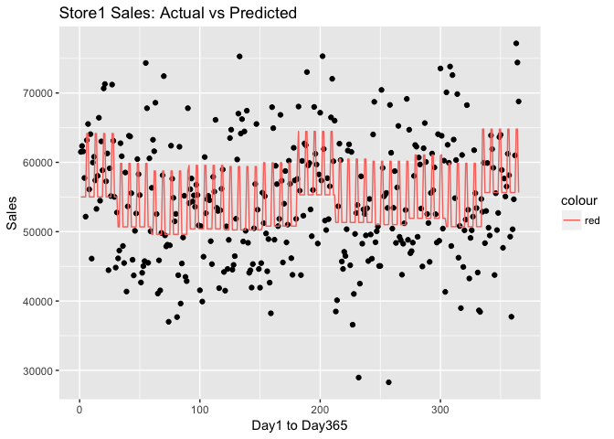

```r
ggplot( data = DataA[1:365,]) + geom_point( aes(x = c(1:365),
                                       y = Sales)) +
  geom_line( aes( x = c(1:365),
                  y = Model.A$fitted.values[1:365],
                  colour = 'red')) +
  labs( x = 'Day1 to Day365',
        y = 'Sales',
        title = 'Store1 Sales: Actual vs Predicted')
```

- 店2的營收

由於店2考慮的因素較少，同樣也存在沒辦法掌握到較極端點的問題

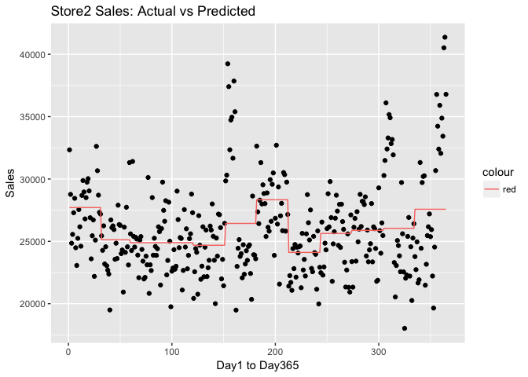

```r
ggplot( data = DataB[1:365,]) + geom_point( aes(x = c(1:365),
                                       y = Sales)) +
  geom_line( aes( x = c(1:365),
                  y = Model.B$fitted.values[1:365],
                  colour = 'red'))  +
  labs( x = 'Day1 to Day365',
        y = 'Sales',
        title = 'Store2 Sales: Actual vs Predicted')
```

### 加入新資訊

在重新搜集資料後，新增了三個欄位：`Holiday`、`Store1_Event`、`Store2_Event`，分別是是否為國定假日、分店一所屬的百貨特別活動和分店二所屬的百貨特別活動。

```r
SalesDataRenew <- read.csv('Restaurant_Sales_Renew.csv')

kable( SalesDataRenew[1:10,], row.names = F, caption = '新增資料')
```

新增資料

| Store_Name | Region | Type | Weekday | Month | Sales | Holiday | Store1_Event | Store2_Event |
| --- | --- | --- | --- | --- | --- | --- | --- | --- |
| 1 | A | AA | Weekday | Jan | 61508 | 1 | 0 | 0 |
| 1 | A | AA | Weekday | Jan | 62358 | 1 | 0 | 0 |
| 1 | A | AA | Weekday | Jan | 61579 | 0 | 0 | 0 |
| 1 | A | AA | Weekday | Jan | 57747 | 0 | 0 | 0 |
| 1 | A | AA | Weekday | Jan | 52169 | 0 | 0 | 0 |
| 1 | A | AA | Weekend | Jan | 63197 | 0 | 0 | 0 |
| 1 | A | AA | Weekend | Jan | 65528 | 0 | 0 | 0 |
| 1 | A | AA | Weekday | Jan | 56107 | 0 | 0 | 0 |
| 1 | A | AA | Weekday | Jan | 64067 | 0 | 0 | 0 |
| 1 | A | AA | Weekday | Jan | 46116 | 0 | 0 | 0 |

### 檢視新變數對營收的影響

```r
Model.Holiday <- lm( Sales ~ Holiday, data = SalesDataRenew)

Event <- ifelse( SalesDataRenew$Store1_Event %in% 1 | SalesDataRenew$Store2_Event %in% 1, 1, 0)
Model.Event <- lm( SalesDataRenew$Sales ~ Event)
```

新的變數對於整體營收皆有顯著的影響，因此我們決定納入之後的建模

```r
summary(Model.Holiday)
```

```
##
## Call:
## lm(formula = Sales ~ Holiday, data = SalesDataRenew)
##
## Residuals:
##    Min     1Q Median     3Q    Max
## -20207 -10450  -5001   7941  42395
##
## Coefficients:
##             Estimate Std. Error t value Pr(>|t|)
## (Intercept)  32918.2      380.1  86.598  < 2e-16 ***
## Holiday       4144.6     1584.8   2.615  0.00901 **
## ---
## Signif. codes:  0 '***' 0.001 '**' 0.01 '*' 0.05 '.' 0.1 ' ' 1
##
## Residual standard error: 14100 on 1458 degrees of freedom
## Multiple R-squared:  0.004669,   Adjusted R-squared:  0.003987
## F-statistic:  6.84 on 1 and 1458 DF,  p-value: 0.009007
```

```r
summary(Model.Event)
```

```
##
## Call:
## lm(formula = SalesDataRenew$Sales ~ Event)
##
## Residuals:
##    Min     1Q Median     3Q    Max
## -19880 -10323  -5044   8106  42722
##
## Coefficients:
##             Estimate Std. Error t value Pr(>|t|)
## (Intercept)  32590.8      369.5  88.195  < 2e-16 ***
## Event        14750.8     1886.8   7.818 1.02e-14 ***
## ---
## Signif. codes:  0 '***' 0.001 '**' 0.01 '*' 0.05 '.' 0.1 ' ' 1
##
## Residual standard error: 13850 on 1458 degrees of freedom
## Multiple R-squared:  0.04023,    Adjusted R-squared:  0.03957
## F-statistic: 61.12 on 1 and 1458 DF,  p-value: 1.024e-14
```

### 將全部資料進行建模

這邊我們先跳出之前的假設，嘗試將區域的差異納入模型中，試著討論模型能否學習到區域間的差異，進而產生更好的解釋能力

```r
Model.All <- lm( Sales ~ ., data = SalesDataRenew[,-1])
summary(Model.All)
```

```
##
## Call:
## lm(formula = Sales ~ ., data = SalesDataRenew[, -1])
##
## Residuals:
##    Min     1Q Median     3Q    Max
## -19189  -4616  -1300   4743  22425
##
## Coefficients:
##                Estimate Std. Error t value Pr(>|t|)
## (Intercept)     46790.2      607.8  76.978  < 2e-16 ***
## RegionB        -19919.5      320.1 -62.220  < 2e-16 ***
## TypeBB         -13484.6      320.9 -42.023  < 2e-16 ***
## WeekdayWeekend   4489.9      348.2  12.896  < 2e-16 ***
## MonthAug          573.7      773.2   0.742 0.458203
## MonthDec         3138.7      777.1   4.039 5.65e-05 ***
## MonthFeb          627.2      790.4   0.793 0.427624
## MonthJan         3967.2      769.1   5.158 2.84e-07 ***
## MonthJul         4679.4      773.1   6.053 1.81e-09 ***
## MonthJun         1132.2      785.8   1.441 0.149827
## MonthMar         -264.1      767.9  -0.344 0.730929
## MonthMay         -860.0      780.8  -1.101 0.270922
## MonthNov         -326.4      794.6  -0.411 0.681287
## MonthOct         1255.3      767.6   1.635 0.102224
## MonthSep          671.3      773.9   0.867 0.385835
## Holiday          3836.7      695.6   5.516 4.12e-08 ***
## Store1_Event    14632.1     1273.6  11.489  < 2e-16 ***
## Store2_Event     4124.0     1155.7   3.569 0.000371 ***
## ---
## Signif. codes:  0 '***' 0.001 '**' 0.01 '*' 0.05 '.' 0.1 ' ' 1
##
## Residual standard error: 5994 on 1442 degrees of freedom
## Multiple R-squared:  0.8221, Adjusted R-squared:   0.82
## F-statistic: 392.1 on 17 and 1442 DF,  p-value: < 2.2e-16
```

整體的`R-squared`上升了，但月份間的差異變得較不顯著

### 用視覺化檢視目前的成果

- 店1的營收

在店1的營收解釋上，此模型在納入新的變數後，表現的確能更抓到營收較高的那幾天

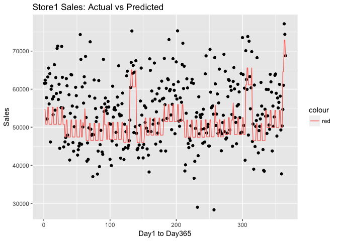

```r
ggplot( data = SalesDataRenew[1:365,]) + geom_point( aes(x = c(1:365),
                                       y = Sales)) +
  geom_line( aes( x = c(1:365),
                  y = Model.All$fitted.values[1:365],
                  colour = 'red')) +
  labs( x = 'Day1 to Day365',
        y = 'Sales',
        title = 'Store1 Sales: Actual vs Predicted')
```

- 店2的營收 但在店2的營收中，雖然也因為百貨活動抓到了較高的幾天，由於店2屬於百貨門市的類型，模型對它的營收估計較高，所以整體而言明顯高估

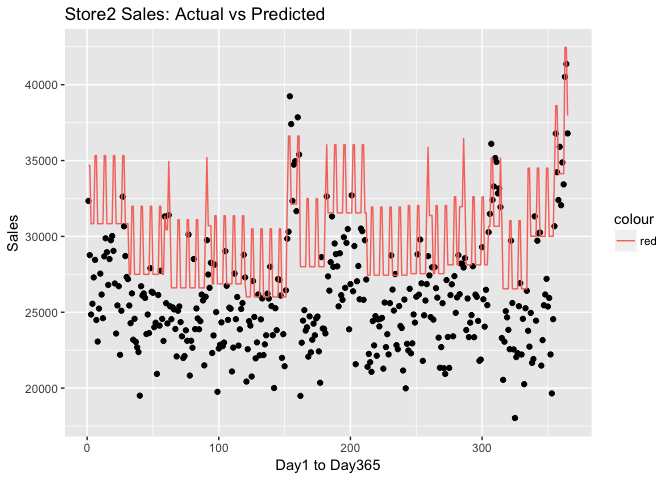

```r
ggplot( data = SalesDataRenew[366:730,]) + geom_point( aes(x = c(1:365),
                                       y = Sales)) +
  geom_line( aes( x = c(1:365),
                  y = Model.All$fitted.values[366:730],
                  colour = 'red')) +
  labs( x = 'Day1 to Day365',
        y = 'Sales',
        title = 'Store2 Sales: Actual vs Predicted')
```

- 四間店

區域和門市類型的差異影響了模型的解釋與判斷，因此將四間店的資料納入同一個模型並非最好的做法

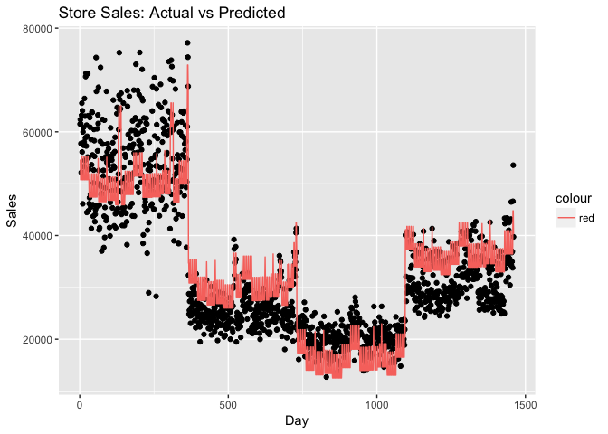

```r
ggplot( data = SalesDataRenew) + geom_point( aes(x = c(1:1460),
                                       y = Sales)) +
  geom_line( aes( x = c(1:1460),
                  y = Model.All$fitted.values,
                  colour = 'red')) +
  labs( x = 'Day',
        y = 'Sales',
        title = 'Store Sales: Actual vs Predicted')
```

- Beta Coefficients

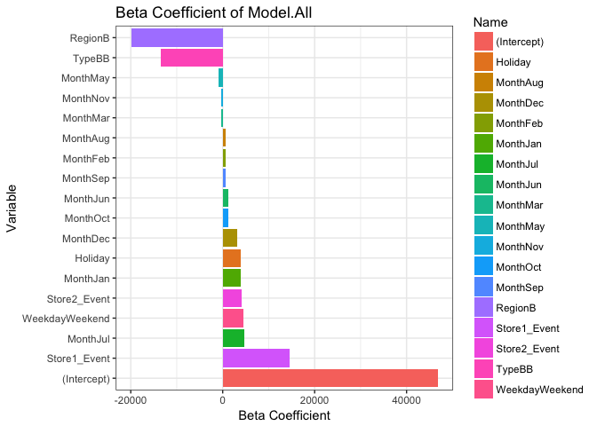

```r
Beta <- cbind(
  names(Model.All$coefficients),
  Model.All$coefficients
) %>%
  as.data.frame()

colnames(Beta) <- c('Name', 'Value')
Beta$Value <- Beta$Value %>% as.character() %>% as.numeric()

Beta <- Beta %>%
  arrange(desc(Value))

ggplot( data = Beta) +
  geom_bar(aes( x = factor(Name, levels = as.character(Beta$Name)),
             y = Value,
             fill = Name),stat = 'identity') +

    labs( x = 'Variable',
          y = 'Beta Coefficient',
          title = 'Beta Coefficient of Model.All') + coord_flip() + theme_bw()
```

### 用更新資料分區域預測

這邊納入了一個新觀念：`交互作用(interaction)`，在前面的建模過程中，我們觀察到不同門市類型的平假日表現可能有所不同，因此我們用`Var1 * Var2`這樣的方式表示兩個變數間互相的影響，會對目標變數造成什麼樣的效果。

```r
DataRenewA <- SalesDataRenew %>% filter( Region %in% 'A')
DataRenewB <- SalesDataRenew %>% filter( Region %in% 'B')


Model.A.All <- lm( Sales ~ .+ Type * Weekday, data = DataRenewA[,-c(1,2)])
Model.B.All <- lm( Sales ~ .+ Type * Weekday , data = DataRenewB[,-c(1,2)])
```

在這裡可以看到，加入交互作用後，區域B的平假日影響也變得顯著，更值得注意的是在兩個模型中，屬於BB的門市類型在遇到假日時，對於營收反而有顯著的負面影響。

```r
summary(Model.A.All)
```

```
##
## Call:
## lm(formula = Sales ~ . + Type * Weekday, data = DataRenewA[,
##     -c(1, 2)])
##
## Residuals:
##      Min       1Q   Median       3Q      Max
## -21660.2  -2526.9    -15.1   2573.0  17079.4
##
## Coefficients: (1 not defined because of singularities)
##                       Estimate Std. Error t value Pr(>|t|)
## (Intercept)            49049.6      673.5  72.827  < 2e-16 ***
## TypeBB                -21033.5      425.8 -49.395  < 2e-16 ***
## WeekdayWeekend         10384.6      557.2  18.638  < 2e-16 ***
## MonthAug                1569.6      875.6   1.793 0.073472 .
## MonthDec                4572.7      874.1   5.231 2.22e-07 ***
## MonthFeb                 760.2      895.1   0.849 0.396005
## MonthJan                4933.6      871.0   5.664 2.14e-08 ***
## MonthJul                5556.4      875.5   6.347 3.91e-10 ***
## MonthJun                1046.8      882.5   1.186 0.235981
## MonthMar                -623.8      869.6  -0.717 0.473384
## MonthMay               -1182.4      894.3  -1.322 0.186515
## MonthNov                -765.9      902.3  -0.849 0.396251
## MonthOct                1520.1      869.3   1.749 0.080785 .
## MonthSep                 597.6      876.3   0.682 0.495520
## Holiday                 4948.8      788.7   6.275 6.07e-10 ***
## Store1_Event           10370.9     1065.8   9.731  < 2e-16 ***
## Store2_Event                NA         NA      NA       NA
## TypeBB:WeekdayWeekend  -2604.8      787.2  -3.309 0.000983 ***
## ---
## Signif. codes:  0 '***' 0.001 '**' 0.01 '*' 0.05 '.' 0.1 ' ' 1
##
## Residual standard error: 4799 on 713 degrees of freedom
## Multiple R-squared:  0.8717, Adjusted R-squared:  0.8688
## F-statistic: 302.7 on 16 and 713 DF,  p-value: < 2.2e-16
```

```r
summary(Model.B.All)
```

```
##
## Call:
## lm(formula = Sales ~ . + Type * Weekday, data = DataRenewB[,
##     -c(1, 2)])
##
## Residuals:
##     Min      1Q  Median      3Q     Max
## -6975.2 -1328.0    -2.8  1387.3  6575.0
##
## Coefficients: (1 not defined because of singularities)
##                       Estimate Std. Error t value Pr(>|t|)
## (Intercept)           23613.43     292.17  80.822  < 2e-16 ***
## TypeBB                -3927.20     185.06 -21.221  < 2e-16 ***
## WeekdayWeekend         1830.88     241.82   7.571 1.15e-13 ***
## MonthAug               -420.89     379.75  -1.108  0.26809
## MonthDec               1131.54     384.68   2.941  0.00337 **
## MonthFeb                495.56     388.18   1.277  0.20216
## MonthJan               3000.77     377.74   7.944 7.64e-15 ***
## MonthJul               3804.64     379.68  10.021  < 2e-16 ***
## MonthJun                357.55     389.69   0.918  0.35918
## MonthMar                 95.96     377.15   0.254  0.79923
## MonthMay                150.98     379.75   0.398  0.69107
## MonthNov                -37.82     389.77  -0.097  0.92273
## MonthOct                989.28     377.01   2.624  0.00888 **
## MonthSep                745.98     380.06   1.963  0.05006 .
## Holiday                2743.14     341.32   8.037 3.83e-15 ***
## Store1_Event                NA         NA      NA       NA
## Store2_Event           9299.63     422.72  21.999  < 2e-16 ***
## TypeBB:WeekdayWeekend -3925.71     341.56 -11.493  < 2e-16 ***
## ---
## Signif. codes:  0 '***' 0.001 '**' 0.01 '*' 0.05 '.' 0.1 ' ' 1
##
## Residual standard error: 2081 on 713 degrees of freedom
## Multiple R-squared:  0.7738, Adjusted R-squared:  0.7687
## F-statistic: 152.4 on 16 and 713 DF,  p-value: < 2.2e-16
```

### Region A

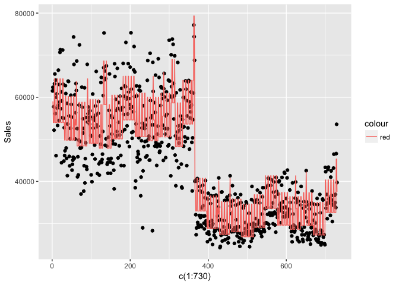

```r
ggplot( data = DataRenewA) + geom_point( aes(x = c(1:730),
                                       y = Sales)) +
  geom_line( aes( x = c(1:730),
                  y = Model.A.All$fitted.values,
                  colour = 'red'))
```

### Region B

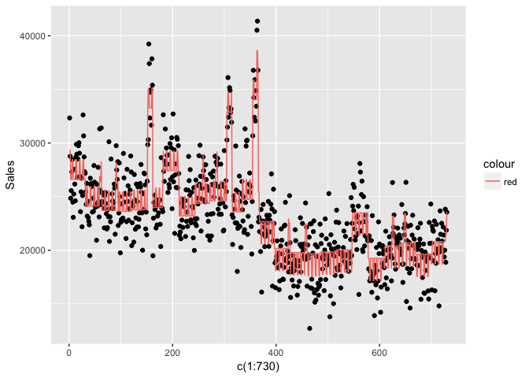

```r
ggplot( data = DataRenewB) + geom_point( aes(x = c(1:730),
                                       y = Sales)) +
  geom_line( aes( x = c(1:730),
                  y = Model.B.All$fitted.values,
                  colour = 'red'))
```

### 探討模型的準確度及誤差

- 誤差：以`RMSE`衡量(Root-Mean-Square Error)

```r
RMSE <- function( predict, actual){
  result <- sqrt(mean((predict - actual) ^ 2))
  return(result)
}

cat('RegionA模型的RMSE：\n',RMSE(Model.A.All$fitted.values, DataRenewA$Sales),'\n',sep = '')
```

```
## RegionA模型的RMSE：
## 4743.127
```

```r
cat('RegionB模型的RMSE：\n',RMSE(Model.B.All$fitted.values, DataRenewB$Sales),'\n',sep ='')
```

```
## RegionB模型的RMSE：
## 2057.058
```

- 誤差：以`MAPE`衡量(Mean Absolute Percentage Error)

```r
MAPE <- function( predict, actual){
  result <- mean(abs((predict - actual)/actual)) %>% round(3) * 100
  return(result)
}

cat('RegionA模型的MAPE：\n',MAPE(Model.A.All$fitted.values, DataRenewA$Sales),'%','\n',sep='')
```

```
## RegionA模型的MAPE：
## 7.8%
```

```r
cat('RegionB模型的MAPE：\n',MAPE(Model.B.All$fitted.values, DataRenewB$Sales),'%','\n',sep='')
```

```
## RegionB模型的MAPE：
## 7.3%
```

## 連鎖餐飲區域經理的決策

### 營收分析：Region A

從beta coefficient的數值中，我們可以得知，在區域A中：

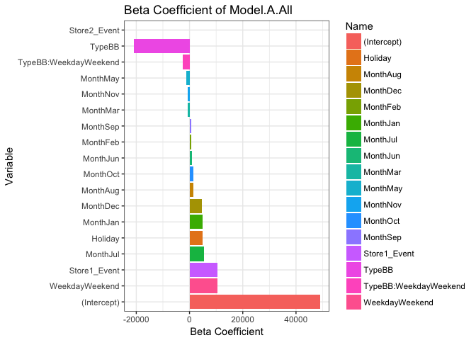

### 營收分析：Region B

從beta coefficient的數值中，我們可以得知，在區域B中：

- 百貨門市(AA)的表現較一般門市(BB)來得優異
- 在各月份中，7月月和1月是明顯的旺季，對營收的影響甚至超過國定假日
- Store2的百貨促銷活動對營收有正面的影響，建議可以加強此時段的促銷配合
- 值得注意的是，一般門市在假日時營收會明顯下滑，推論為商業區的一般門市在假日時有較少的來客，應針對此點進行改善

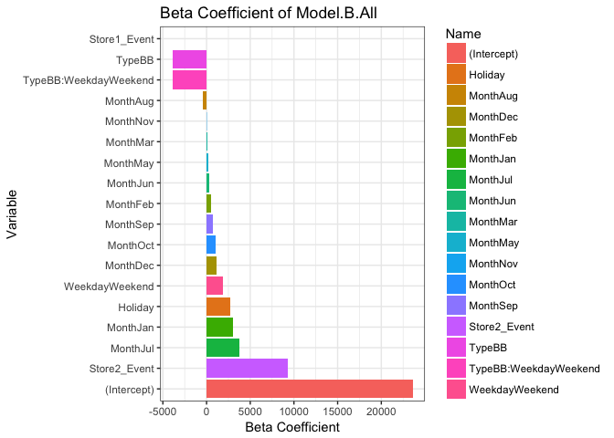

### 營業目標及展店的營收估計

在下一個年度的訂定每日或每週的營業目標時，能參考模型的預測，並將預測的誤差當作容許的範圍，以店1的一月份為例：

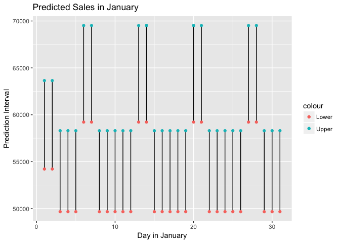

```r
January <- tibble( 'Day' = c(1:31),
                   'Sales_Upperbound' = Model.A.All$fitted.values[1:31] * 1.08,
                   'Sales_Lowerbound' = Model.A.All$fitted.values[1:31] * 0.92)

ggplot( data = January)  +
  geom_segment(aes(x=Day, xend=Day,
                   y=Sales_Upperbound, yend=Sales_Lowerbound)) +
  geom_point(  aes( x = Day,
                    y = Sales_Upperbound,
               colour = "Upper")) +
  geom_point( aes( x = Day,
                   y = Sales_Lowerbound,
              colour = 'Lower')) +
  labs( x = 'Day in January',
        y = 'Prediction Interval',
        title = 'Predicted Sales in January')
```